# State Farm Distracted Drivers

Prev Exercises: Udacity:DeepLearning:TensorFlow:notMNIST

## Fit Logistic Regression (TensorFlow)

```python
import sys
print sys.version

from joblib import Parallel, delayed
import multiprocessing
nCores = multiprocessing.cpu_count() - 2 # Allow other apps to run
print 'nCores: %d' % (nCores)

from datetime import datetime, time
print 'now: %s' % str(datetime.now())
```

```
2.7.11 (default, Jan 28 2016, 14:07:46)
[GCC 4.2.1 Compatible Apple LLVM 7.0.2 (clang-700.1.81)]
nCores: 14
now: 2016-05-19 19:23:49.291920
```

```python
import matplotlib.pyplot as plt
%matplotlib inline
from IPython.display import display, Image
import rpy2.robjects as robjects
from rpy2.robjects.packages import importr
from rpy2.robjects.lib import grid
from rpy2.robjects.lib import ggplot2
import rpy2.robjects.pandas2ri

import numpy as np
np.set_printoptions(precision=4, suppress=True)
import os
import pandas as pd
from scipy import ndimage
from six.moves.urllib.request import urlretrieve
from six.moves import cPickle as pickle

import tensorflow as tf
print 'tf.__version__:%s' % str(tf.__version__)

%run img_utils.py
```

```
tf.__version__:0.8.0
```

## Analytics Specs

### This Project

```python
%run img_glbSpec_SFDD_ImgSz_64.py
```

```
imported img_glbSpec_SFDD_Img_Sz_64.py
```

```python
# print '\nglbDataFile: %s' % (glbDataFile)

print '\nglbRspClass: %s' % (glbRspClass)
print 'glbRspClassN: %d' % (glbRspClassN)
print 'glbRspClassDesc: '; print(glbRspClassDesc)

print '\nglbImg:'; print(glbImg)

print '\nglbTfwVarSeed: %d' % (glbTfwVarSeed)

print '\nglbPickleFile: %s' % (glbPickleFile)
```

```
glbRspClass: ['c0', 'c1', 'c2', 'c3', 'c4', 'c5', 'c6', 'c7', 'c8', 'c9']
glbRspClassN: 10
glbRspClassDesc:
{'c9': 'talking to passenger', 'c8': 'hair and makeup', 'c3': 'texting - left', 'c2': 'talking on the phone - right', 'c1': 'texting - right', 'c0': 'normal driving', 'c7': 'reaching behind', 'c6': 'drinking', 'c5': 'operating the radio', 'c4': 'talking on the phone - left'}

glbImg:
{'color': False, 'crop': {'x': (80, 560)}, 'shape': (480, 640, 3), 'pxlDepth': 255.0, 'center_scale': True, 'size': 64}

glbTfwVarSeed: 131

glbPickleFile: {'models': 'data/img_M_SFDD_ImgSz_64.pickle', 'data': 'data/img_D_SFDD_ImgSz_64.pickle'}
```

## Import Data

### This Project

```python
%run img_utils.py
glbObsFitIdn, glbObsFitFtr, glbObsFitRsp, \
glbObsVldIdn, glbObsVldFtr, glbObsVldRsp, \
glbObsNewIdn, glbObsNewFtr, glbObsNewRsp, \
sbtNewCorDf, \
_ = myimportDbs(glbPickleFile['data'])

glbObsTrnIdn = glbObsFitIdn + glbObsVldIdn
glbObsTrnFtr = np.vstack((glbObsFitFtr, glbObsVldFtr))
glbObsTrnRsp = np.concatenate((glbObsFitRsp, glbObsVldRsp))

print('Fit pickled set:',
      len(glbObsFitIdn), glbObsFitFtr.shape, glbObsFitRsp.shape)
print('Vld pickled set:',
      len(glbObsVldIdn), glbObsVldFtr.shape, glbObsVldRsp.shape)
print('Trn pickled set:',
      len(glbObsTrnIdn), glbObsTrnFtr.shape, glbObsTrnRsp.shape)
print('New pickled set:',
      len(glbObsNewIdn), glbObsNewFtr.shape, glbObsNewRsp.shape)
```

```
Importing database from data/img_D_SFDD_ImgSz_64.pickle...
('Fit pickled set:', 18077, (18077, 64, 64), (18077,))
('Vld pickled set:', 4347, (4347, 64, 64), (4347,))
('Trn pickled set:', 22424, (22424, 64, 64), (22424,))
('New pickled set:', 79726, (79726, 64, 64), (79726,))
```

First reload the data we generated in `1_notmist.ipynb`.

```python
# pickle_file = 'data/notMNIST.pickle'

# with open(pickle_file, 'rb') as f:
#   save = pickle.load(f)
#   glbXFit = save['glbXFit']
#   glbYFit = save['glbYFit']
#   glbXVld = save['glbXVld']
#   glbYVld = save['glbYVld']
#   glbXNew = save['glbXNew']
#   glbYNew = save['glbYNew']
#   del save  # hint to help gc free up memory
#   print('Training set', glbXFit.shape, glbYFit.shape)
#   print('Validation set', glbXVld.shape, glbYVld.shape)
#   print('Test set', glbXNew.shape, glbYNew.shape)
```

Reformat into a shape that's more adapted to the models we're going to train:

- data as a flat matrix,
- labels as float 1-hot encodings.

```python
def lclreformatData(I, X, Y):
  X = X.reshape((-1, glbImg['size'] * glbImg['size'])).astype(np.float32)
  # Map 0 to [1.0, 0.0, 0.0 ...], 1 to [0.0, 1.0, 0.0 ...]
  Y = (np.arange(glbRspClassN) == Y[:,None]).astype(np.float32)
  return I, X, Y

glbITrn, glbXTrn, glbYTrn = lclreformatData(
    glbObsTrnIdn, glbObsTrnFtr, glbObsTrnRsp)
glbIFit, glbXFit, glbYFit = lclreformatData(
    glbObsFitIdn, glbObsFitFtr, glbObsFitRsp)
glbIVld, glbXVld, glbYVld = lclreformatData(
    glbObsVldIdn, glbObsVldFtr, glbObsVldRsp)
glbINew, glbXNew, glbYNew = lclreformatData(
    glbObsNewIdn, glbObsNewFtr, glbObsNewRsp)

print('Trn reshaped set:', len(glbITrn), glbXTrn.shape, glbYTrn.shape)
print('Fit reshaped set:', len(glbIFit), glbXFit.shape, glbYFit.shape)
print('Vld reshaped set:', len(glbIVld), glbXVld.shape, glbYVld.shape)
print('New reshaped set:', len(glbINew), glbXNew.shape, glbYNew.shape)
```

```
('Trn reshaped set:', 22424, (22424, 4096), (22424, 10))
('Fit reshaped set:', 18077, (18077, 4096), (18077, 10))
('Vld reshaped set:', 4347, (4347, 4096), (4347, 10))
('New reshaped set:', 79726, (79726, 4096), (79726, 10))
```

```python
# Check how much incremental memory is used for Trn obs
del glbObsTrnIdn, glbObsTrnFtr, glbObsTrnRsp
del glbITrn, glbXTrn, glbYTrn
```

```python
print glbObsTrnFtr.shape
```

[output not shown]

```python
# glbImg['size'] = 28
# glbRspClassN = 10

# def reformat(dataset, labels):
#   dataset = dataset.reshape((-1, glbImg['size'] * glbImg['size'])).astype(np.float32)
#   # Map 0 to [1.0, 0.0, 0.0 ...], 1 to [0.0, 1.0, 0.0 ...]
#   labels = (np.arange(glbRspClassN) == labels[:,None]).astype(np.float32)
#   return dataset, labels
# glbXFit, glbYFit = reformat(glbXFit, glbYFit)
# glbXVld, glbYVld = reformat(glbXVld, glbYVld)
# glbXNew, glbYNew = reformat(glbXNew, glbYNew)
# print('Training set', glbXFit.shape, glbYFit.shape)
# print('Validation set', glbXVld.shape, glbYVld.shape)
# print('Test set', glbXNew.shape, glbYNew.shape)
```

## Fit Logistic Regression (TensorFlow)

We're first going to train a multinomial logistic regression using simple gradient descent.

TensorFlow works like this:

- First you describe the computation that you want to see performed: what the inputs, the variables, and the operations look like. These get created as nodes over a computation graph. This description is all contained within the block below:

  ```
  with graph.as_default():
      ...
  ```

- Then you can run the operations on this graph as many times as you want by calling `session.run()`, providing it outputs to fetch from the graph that get returned. This runtime operation is all contained in the block below:

  ```
  with tf.Session(graph=graph) as session:
      ...
  ```

Let's load all the data into TensorFlow and build the computation graph corresponding to our training:

```python
print "glbYNew[:5, :]:" % ()
print glbYNew[:5, :]
```

```
glbYNew[:5, :]:
[[ 0.  0.  0.  0.  0.  0.  0.  0.  0.  0.]
 [ 0.  0.  0.  0.  0.  0.  0.  0.  0.  0.]
 [ 0.  0.  0.  0.  0.  0.  0.  0.  0.  0.]
 [ 0.  0.  0.  0.  0.  0.  0.  0.  0.  0.]
 [ 0.  0.  0.  0.  0.  0.  0.  0.  0.  0.]]
```

```python
%run img_glbSpec_SFDD_ImgSz_64.py
%run img_utils.py

# Add parameter for lrnRateTfw = 0.5 for GradientDescentOptimizer

# With gradient descent training, even this much data is prohibitive.
# Subset the training data for faster turnaround.
def fitMdlLgtRgrTfw(lclXFit, lclYFit,
                    nObsFit = 50, nStepsTfw = 11, lrnRateTfw = 0.5,
                    visualize = False, newObs = False, verbose = False):

    from sklearn import metrics as skl_metrics

    print('\nLogistic Regression (TensorFlow): ' + \
          "nObsFit:%5d; nStepsTfw:%5d; lrnRateTfw:%.4f" % ( \
            nObsFit, nStepsTfw, lrnRateTfw))
    print("  visualize: %s; newObs: %s; verbose: %s" % ( \
            visualize, newObs, verbose))

    startTm = datetime.now()

    mdlDf = pd.DataFrame({'id': 'LgtRgr.tfw',
                             'nObsFit'  : [nObsFit],
                             'nStepsTfw': [nStepsTfw],
                            'lrnRateTfw': [lrnRateTfw]
                         })

    graph = tf.Graph()
    with graph.as_default():

      # Input data.
      # Load the training, validation and test data into constants that
      #  are attached to the graph.
      tfwXFit = tf.constant(lclXFit[:nObsFit, :])
      tfwYFit = tf.constant(lclYFit[:nObsFit])
      tfwXVld = tf.constant(glbXVld)
      tfwYVld = tf.constant(glbYVld)
      # Create placeholders for ObsNew & occlusion visualization
      tfwXNew = tf.placeholder(tf.float32,
                shape = (glbImg['size'], lclXFit.shape[1]))
      tfwYNew = tf.placeholder(tf.float32,
                shape = (glbImg['size'], lclYFit.shape[1]))

      # Variables.
      tf.set_random_seed(glbTfwVarSeed)

      # These are the parameters that we are going to be training.
      # The weight matrix will be initialized using random valued
      # following a (truncated) normal distribution.
      # The bias vector get initialized to zero.
      tfwW = tf.Variable(
        tf.truncated_normal([glbImg['size'] * glbImg['size'],
                             glbRspClassN]),
        name = 'tfwW')
      tfwB = tf.Variable(tf.zeros([glbRspClassN]), name = 'tfwB')
      if (verbose):
          print('  tfwW:', tfwW.initialized_value())
          print('  tfwB:', tfwB.initialized_value())
#         print 'lblIx:%2d:%s'% \
#     (np.vectorize("%.4e".__mod__)(tfwW.value()[:5, lblIx]))

      # Training computation.
      # We multiply the inputs with the weight matrix, and add bias.
      # We compute the softmax and cross-entropy (it's one operation in
      # TensorFlow, because it's very common, and it can be optimized).
      # We take the average of this cross-entropy across all training
      # examples: that's our loss.
      logits = tf.matmul(tfwXFit, tfwW) + tfwB
      loss = tf.reduce_mean(
        tf.nn.softmax_cross_entropy_with_logits(logits, tfwYFit))

      # Optimizer.
      # We are going to find the minimum of this loss using
      #  gradient descent.
      optimizer = (tf.train
                   .GradientDescentOptimizer(tf.to_float(lrnRateTfw))
                   .minimize(loss))

      # Predictions for the training, validation, and test data.
      # These are not part of training, but merely here so that we can
      # report accuracy_score figures as we train.
      tfwYFitPby = tf.nn.softmax(logits)
      tfwYVldPby = tf.nn.softmax(tf.matmul(tfwXVld, tfwW) + tfwB)
      tfwYNewPby = tf.nn.softmax(tf.matmul(tfwXNew, tfwW) + tfwB)
#       print '  fitMdlLgtRgrTfw: type(tfwYOccPby): %s' % \
#             (type(tfwYOccPby))
#       print '  fitMdlLgtRgrTfw: ' + \
#             tfwYOccPby.get_shape().as_list(): %s' % \
#         (tfwYOccPby.get_shape().as_list())

    def accuracy_score(predictions, labels):
      return (1.0 * np.sum(np.argmax(predictions, 1) ==
                           np.argmax(labels, 1))
              / predictions.shape[0])

    tf.set_random_seed(glbTfwVarSeed)
    with tf.Session(graph=graph) as session:
      # This is a one-time operation which ensures the parameters get
      # initialized as we described in the graph:
      # random tfwW for the matrix, zeros for the tfwB.
      tf.initialize_all_variables().run()
      if verbose:
          print('  Initialized')

      # Create a dummy feed for occlusion visualization
#       print "  fitMdlLgtRgrTfw: lclXFit.shape: %s" % \
#         str(lclXFit.shape)
#       print "  fitMdlLgtRgrTfw: " + \
#             "lclXFit[:glbImg['size'], :].shape: %s" % \
#         str(lclXFit[:glbImg['size'], :].shape)
      feed_dict = {tfwXNew: glbXNew[:glbImg['size'], :]}
      for step in range(int(nStepsTfw)):
        # Run the computations.
        # We tell .run() that we want to run the optimizer,
        # and get the loss value and the training predictions returned
        # as numpy arrays.
        _, l, predictions = \
            session.run([optimizer, loss, tfwYFitPby],
                        feed_dict = feed_dict)

        if mydspVerboseTrigger(step):
          thsDrn = (datetime.now() - startTm).seconds
          if (thsDrn > 100):
              print('  logLoss at step %5d: %.4f (%d secs)' % \
                    (step, l, thsDrn))

      accFit = accuracy_score(tfwYFitPby.eval()[:nObsFit, :],
                              tfwYFit.eval()   [:nObsFit, :])
      logLossFit = \
        skl_metrics.log_loss(tfwYFit.eval()   [:nObsFit, :],
                             tfwYFitPby.eval()[:nObsFit, :])
      if verbose:
        print '\n  Fit accuracy:%0.4f' % (accFit)
        print   '  Fit  logLoss:%0.4f' % (logLossFit)
    #         print metrics.confusion_matrix(glbYFit[0:nObsFit],
    #                                         lclYFitPdn)

      # Calling .eval() on tfwObsVldPred is basically like calling run(),
      # but just to get that one numpy array.
      # Note that it recomputes all its graph dependencies.

      lclYVldPby = tfwYVldPby.eval()
      lclYVldPdn = np.argmax(lclYVldPby, 1)
      mdlDf['accVld'] = accVld = accuracy_score(lclYVldPby, glbYVld)
      cnfYVld = skl_metrics.confusion_matrix(glbObsVldRsp, lclYVldPdn)
      accYVldCls = cnfYVld.diagonal() * 1.0 / cnfYVld.sum(axis = 1)
      mdlDf['accVldCls'] = None
      mdlDf.set_value(0, 'accVldCls', {'accCls' : accYVldCls})
```

```python
      mdlDf['logLossVld'] = logLossVld = skl_metrics.log_loss(
                                                glbYVld, lclYVldPby)
      logLossVldCls = mygetMetricLogLoss(glbYVld, lclYVldPby,
                                         returnTyp = 'class')
      mdlDf['logLossVldCls'] = None
      mdlDf.set_value(0, 'logLossVldCls',
                      {'logLossCls' : logLossVldCls})

      if verbose:
        print '\n  Vld accuracy:%0.4f' % (accVld)
        print accYVldCls
        print cnfYVld
        yLbl = [glbRspClassDesc[glbRspClass[ix]] + ':' + \
                  glbRspClass[ix] + ':actl' \
                for ix in xrange(glbRspClassN)]
        xLbl = ['pred:' + glbRspClass[ix] + ':' + \
                glbRspClassDesc[glbRspClass[ix]] \
                   for ix in xrange(glbRspClassN)]
        # print labels
        plt.matshow(cnfYVld, cmap='Reds', interpolation='none')
        plt.yticks(np.arange(10), yLbl)
        plt.xticks(np.arange(10), xLbl, rotation=90);
        plt.show()

        print '\n  Vld  logLoss:%0.4f' % (logLossVld)
        print logLossVldCls

      if visualize:
        mydisplayImagePredictions(session, tfwW.eval(),
                glbIVld, glbObsVldFtr, glbObsVldRsp, lclYVldPby,
                glbRspClass, glbRspClassDesc, imgVisualFn = None,
                            tfwXOcc = tfwXNew, tfwYOccPby = tfwYNewPby)

      if newObs:
          print "  predicting %5d new obs..." % (glbYNew.shape[0])
          lclYNewPby = np.zeros((glbYNew.shape[0],
                                 tfwYFitPby.get_shape().as_list()[1]))
          lclYNewPby[:, :] = -1.0
          btcSz = tfwXNew.get_shape().as_list()[0]
          for obsIx in xrange(0, glbYNew.shape[0], btcSz):
            if mydspVerboseTrigger(obsIx) and \
              (datetime.now() - startTm).seconds > 60:
                print "    @%5d secs: obsIx: %5d" % \
                    ((datetime.now() - startTm).seconds, obsIx)
            obsEnd = obsIx + btcSz
            if obsEnd > lclYNewPby.shape[0]:
                obsEnd = lclYNewPby.shape[0]
            btcYNewPby = session.run(tfwYNewPby,
                feed_dict = {tfwXNew: glbXNew[obsIx:obsEnd, :] \
                    if obsEnd != lclYNewPby.shape[0] \
                    else np.vstack((glbXNew[obsIx:obsEnd, :],
                            glbXNew[0:((obsIx + btcSz) % obsEnd), :]))
                                })
            lclYNewPby[obsIx:obsEnd, :] = btcYNewPby[:, :] \
                                if obsEnd != lclYNewPby.shape[0] \
                                else btcYNewPby[:(obsEnd - obsIx), :]

          assert (lclYNewPby[:, :] != -1.0).all(), \
            'some cells in lclYNewPby == -1.0'
#           lclYNewPdn      = tfwYNew.eval()
#           lclYNewPby = tfwYNewPby.eval()
          lclYNewPdn = np.argmax(lclYNewPby, 1)
          #if (tfwYNew.eval() > -1).any():
          if (len(np.unique(glbYNew, return_counts = True)[0]) > 1):
              mdlDf['accNew'] = accNew = accuracy_score(lclYNewPby,
                                                        glbYNew)
              mdlDf['logLossNew'] = logLossNew = skl_metrics.log_loss(
                                                glbYNew, lclYNewPby)
              if verbose:
                print '\n  New accuracy:%0.4f' % (accNew)
                print   '  New  logLoss:%0.4f' % (logLossNew)
                print skl_metrics.confusion_matrix(glbObsNewRsp,
                                                   lclYNewPdn)
                yLbl = [glbRspClassDesc[glbRspClass[ix]] + ':' +
                          glbRspClass[ix] + ':actl' \
                        for ix in xrange(glbRspClassN)]
                xLbl = ['pred:' + glbRspClass[ix] + ':' + \
                        glbRspClassDesc[glbRspClass[ix]] \
                           for ix in xrange(glbRspClassN)]
                # print labels
                plt.matshow(skl_metrics.confusion_matrix(glbObsNewRsp,
                                                         lclYNewPdn),
                            cmap='Reds', interpolation='none')
                plt.yticks(np.arange(10), yLbl)
                plt.xticks(np.arange(10), xLbl, rotation=90);
                plt.show()

          if visualize:
              mydisplayImagePredictions(session, tfwW.eval(),
                glbINew, glbObsNewFtr, glbObsNewRsp, lclYNewPby,
                glbRspClass, glbRspClassDesc, imgVisualFn = None,
                        tfwXOcc = tfwXNew, tfwYOccPby = tfwYNewPby)

          mdlDf['predNew'] = None
          mdlDf.set_value(0, 'predNew', {'kntCls' : np.unique(lclYNewPdn,
                                            return_counts = True)})
          if verbose:
            print '\n  New prediction knts:'
            print mdlDf['predNew'][0]

      # indentation (6 spaces) determines scope of this
      #   before session.__exit__ & graph.__exit__
      mdlDf['model'] = session

    mdlDf['duration'] = (datetime.now() - startTm).seconds
    print('  duration: %.2d seconds' % (mdlDf['duration'][0]))

    if not newObs: lclYNewPby = None
    return(mdlDf, lclYVldPby, lclYNewPby)

tmpMdlDf = pd.DataFrame()

# thsMdlDf, thsYVldPby, thsYNewPby = fitMdlLgtRgrTfw(
#     glbXFit, glbYFit,
#     nObsFit = 100, nStepsTfw = 10, lrnRateTfw = 0.5,
#     visualize = True, newObs = True, verbose = True)
# mdlDf = mdlDf.append(thsMdlDf)

# To check if model results are deterministic &
# all run options work separately
# thsMdlDf, thsYVldPby, thsYNewPby = fitMdlLgtRgrTfw(
#     glbXFit, glbYFit,
#     nObsFit = 100, nStepsTfw = 10, lrnRateTfw = 0.5,
#     visualize = True, newObs = False, verbose = False)
# mdlDf = mdlDf.append(thsMdlDf)

thsMdlDf, thsYVldPby, thsYNewPby = fitMdlLgtRgrTfw(
    glbXFit, glbYFit,
    nObsFit = 100, nStepsTfw = 10, lrnRateTfw = 0.5,
    visualize = False, newObs = True, verbose = False)
tmpMdlDf = tmpMdlDf.append(thsMdlDf)

thsMdlDf, thsYVldPby, thsYNewPby = fitMdlLgtRgrTfw(
    glbXFit, glbYFit,
    nObsFit = 100, nStepsTfw = 10, lrnRateTfw = 0.5,
    visualize = False, newObs = False, verbose = True)
tmpMdlDf = tmpMdlDf.append(thsMdlDf)
```

```
imported img_glbSpec_SFDD_Img_Sz_64.py

Logistic Regression (TensorFlow): nObsFit:  100; nStepsTfw:   10; lrnRateTfw:0.5000
  visualize: False; newObs: True; verbose: False
  predicting 79726 new obs...
  duration: 14 seconds

Logistic Regression (TensorFlow): nObsFit:  100; nStepsTfw:   10; lrnRateTfw:0.5000
  visualize: False; newObs: False; verbose: True
('  tfwW:', <tf.Tensor 'Identity:0' shape=(4096, 10) dtype=float32>)
('  tfwB:', <tf.Tensor 'Identity_1:0' shape=(10,) dtype=float32>)
  Initialized

  Fit accuracy:0.2400
  Fit  logLoss:11.9237

  Vld accuracy:0.1449
[ 0.3409  0.1067  0.      0.8104  0.0065  0.0047  0.      0.0114  0.
  0.1018]
[[165  23   0 226  51   5   0   4   0  10]
 [ 49  51   0 377   1   0   0   0   0   0]
 [127  64   0 204  56   0   0   1   0   0]
 [ 30  10   0 359   6   0   0   0   0  38]
 [ 28  20   1 378   3   0   0   0   0  29]
 [ 23  20   0 283  84   2   0   9   0   1]
 [ 78  33   0 310  20   0   0   0   0   2]
 [ 41  29   0 216  51   3   0   4   0   6]
 [ 96   8   0 242  14   2   0   1   0   1]
 [ 91  48   0 217  17   3   1  29   0  46]]
```

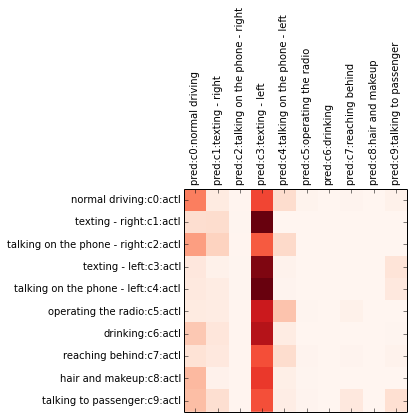

[output not shown]

```python
thsMdlDf, thsYVldPby, thsYNewPby = fitMdlLgtRgrTfw(
    glbXFit, glbYFit,
    nObsFit = 100, nStepsTfw = 10, lrnRateTfw = 0.5,
    visualize = False, newObs = False, verbose = False)
tmpMdlDf = tmpMdlDf.append(thsMdlDf)

# thsMdlDf, thsYVldPby, thsYNewPby = fitMdlLgtRgrTfw(
#     glbXFit, glbYFit,
#     nObsFit = 100, nStepsTfw = 10, lrnRateTfw = 0.1,
#     visualize = False, newObs = False, verbose = True)
# tmpMdlDf = tmpMdlDf.append(thsMdlDf)

print '\ntmpMdlDf: '
print(tmpMdlDf)
```

[output not shown]

[figure not shown]

[output not shown]

```python
lr1MdlDf, lr1YVldPby, lr1YNewPby = fitMdlLgtRgrTfw(
    glbXFit, glbYFit,
    nObsFit = 1000, nStepsTfw = 100, lrnRateTfw = 0.1,
    visualize = False, newObs = True, verbose = True)
```

[output not shown]

[figure not shown]

```
  predicting 79726 new obs...

  New prediction knts:
{'clsKnt': (array([0, 1, 2, 3, 4, 5, 6, 7, 8, 9]), array([12150, 13070, 22283,   135,  4653,  4845,   390,  7545,  5352,  9303]))}
  duration: 19 seconds
```

```python
lr5MdlDf, lr5YVldPby, lr5YNewPby = fitMdlLgtRgrTfw(
    glbXFit, glbYFit,
    nObsFit = 1000, nStepsTfw = 100, lrnRateTfw = 0.5,
    visualize = False, newObs = True, verbose = True)
```

```python
%run img_utils.py
from sklearn import metrics as skl_metrics

def lclaccuracy_score(predictions, labels):
      return (1.0 * np.sum(np.argmax(predictions, 1) ==
                           np.argmax(labels, 1))
              / predictions.shape[0])

print "\nlrnRateTfw: 0.1; accVld: %0.4f" % \
    (lclaccuracy_score(lr1YVldPby, glbYVld))
cnf1YVld = skl_metrics.confusion_matrix(glbObsVldRsp,
                                        np.argmax(lr1YVldPby, 1))
print cnf1YVld
# print cnf1YVld.sum(axis = 1)
print cnf1YVld.diagonal() * 1.0 / cnf1YVld.sum(axis = 1)
# print cnf1YVld.sum(axis = 1).sum()

lls1YVld = skl_metrics.log_loss(glbYVld, lr1YVldPby)
print "\nlrnRateTfw: 0.1; logLossVld: %0.4f" % (lls1YVld)
# lls1YVldCls = np.array([skl_metrics.log_loss(
#                glbYVld[glbYVld[:, clsIx] == 1, :],
#             lr1YVldPby[glbYVld[:, clsIx] == 1, :]) \
#                      for clsIx in range(glbRspClassN)]) / glbRspClassN
# print "lrnRateTfw: 0.1; logLossVld.skl classSum: %0.4f" % (lls1YVld.sum())
# print lls1YVld
lls1YVldCls = mygetMetricLogLoss(glbYVld, lr1YVldPby, returnTyp = 'class')
print "lrnRateTfw: 0.1; logLossVldCls :"; print lls1YVldCls
# print "diff: %.4e" % (np.abs(lls1YVld - lls1YVldCls.sum()))
assert np.abs(lls1YVld - lls1YVldCls.sum()) < 1e-04, \
    "logLoss from skl: %.4f vs myCls %.4f does not match" % \
    (lls1YVld, lls1YVldCls.sum())

print "\nlrnRateTfw: 0.5; accVld: %0.4f" % \
    (lclaccuracy_score(lr5YVldPby, glbYVld))
cnf5YVld = skl_metrics.confusion_matrix(glbObsVldRsp,
                                        np.argmax(lr5YVldPby, 1))
print cnf5YVld
print cnf5YVld.diagonal() * 1.0 / cnf5YVld.sum(axis = 1)

lls5YVld = skl_metrics.log_loss(glbYVld, lr5YVldPby)
print "\nlrnRateTfw: 0.5; logLossVld: %0.4f" % (lls5YVld)
lls5YVldCls = mygetMetricLogLoss(glbYVld, lr5YVldPby, returnTyp = 'class')
print "lrnRateTfw: 0.5; logLossVldCls :"; print lls5YVldCls
assert np.abs(lls5YVld - lls5YVldCls.sum()) < 1e-04, \
    "logLoss from skl: %.4f vs myCls %.4f does not match" % \
    (lls5YVld, lls5YVldCls.sum())
```

```
lrnRateTfw: 0.1; accVld: 0.1735
[[ 73  22  44  15  77   7  94  50  18  84]
 [ 33  68  51  31  24  22  90  77  10  72]
 [ 14 100  61   9 115   1  28 113   2   9]
 [  2  18  29 136  34   7  37  19  10 151]
 [  5  14  17 137  67   9  58  91   3  58]
 [ 11  16  19  41 114  13  14 151  30  13]
 [  9  47  31  55 113   9  45  96  19  19]
 [  1  16  10  14  57  28  45 130  24  25]
 [ 21  12  47  36  47  16  50  66   8  61]
 [  2  12  15   8  38   9  56 140  19 153]]
[ 0.1508  0.1423  0.135   0.307   0.146   0.0308  0.1016  0.3714  0.022
  0.3385]

lrnRateTfw: 0.1; logLossVld: 12.6001
lrnRateTfw: 0.1; logLossVldCls :
[ 1.4741  2.0839  1.4873  0.8025  1.0307  1.8989  1.0157  0.5303  1.2532
  1.0236]

lrnRateTfw: 0.5; accVld: 0.2227
[[148  76  77   0  65   0   4  41   4  69]
 [ 58  87 100   0  44   4   2 121   9  53]
 [ 11  63 120   0 110   0   0 121   0  27]
 [ 10  36  83   1 132   3   3  31   0 144]
 [ 11  19  86   0 197   5  17  53   0  71]
 [ 34   7  66   0  79  35   1 121  38  41]
 [ 33  35 135   0 134   2   1  73   5  25]
 [  2  15  39   0  46  10   0 191  22  25]
 [ 30  24 105   0  40   6   0  62  32  65]
 [ 13  12  87   0  47   6   0 128   3 156]]
[ 0.3058  0.182   0.2655  0.0023  0.4292  0.0829  0.0023  0.5457  0.0879
  0.3451]

lrnRateTfw: 0.5; logLossVld: 13.3804
lrnRateTfw: 0.5; logLossVldCls :
[ 1.0024  1.5107  0.8492  2.5585  0.8238  1.6644  2.5152  0.3775  1.327
  0.7518]
```

```python
glbMdlDf = None
# glbMdlDf = pd.DataFrame()

# try:
#     with open(glbPickleFile['models'], 'rb') as f:
#         glbMdlDf = pickle.load(f)
#         assert isinstance(glbMdlDf, pd.DataFrame), \
#             'type(glbMdlDf): %s, expecting pd.DataFrame' % \
#             (str(type(glbMdlDf)))
# except IOError, e:
#     print e
#     print 'file %s not present or not appropriate' % \
#         (glbPickleFile['models'])
# print glbMdlDf
```

```python
%run img_utils.py
srchParamsDct = {
    'nObsFit' : [glbObsFitFtr.shape[0]],
#     'nObsFit' : [100, 1000, 5000, 10000, glbObsFitFtr.shape[0]]
    'nStepsTfw' : [1000],
#     'nStepsTfw' : [1000, 2000],
    'lrnRateTfw' : [1.0, 10.0]
#     'lrnRateTfw' : [0.1, 1.0, 10.0]
                }

jnk = mysearchParams(fitMdlLgtRgrTfw, srchParamsDct = srchParamsDct,
                     curResultsDf = glbMdlDf,
               mode = 'displayonly',
        sort_values    = ['nObsFit', 'accVld', 'logLossVld', 'duration'],
        sort_ascending = [False    , True    , False,        False],
                save_drop_cols = 'model',
                save_filepathname = glbPickleFile['models'],
              lclXFit = glbXFit, lclYFit = glbYFit)

# thsDf, thsObsVldRspPredProba, thsObsNewRspPredProba = fitMdlLgtRgrTfw(
#     glbXFit, glbYFit,
#     nObsFit = 100, nStepsTfw = 10, lrnRateTfw = 0.5,
#     visualize = False, newObs = False, verbose = False)
```

```
mysearchParams: will run <function fitMdlLgtRgrTfw at 0x11994eed8> with params:
                              nStepsTfw  nObsFit  lrnRateTfw
nStepsTfw nObsFit lrnRateTfw
-1.0      100.0   -1.0           1000.0  18077.0         1.0
```

```python
%run img_utils.py

glbMdlDf = mysearchParams(fitMdlLgtRgrTfw, srchParamsDct = srchParamsDct,
                     curResultsDf = glbMdlDf,
               mode = 'run',
        sort_values    = ['nObsFit', 'accVld', 'logLossVld', 'duration'],
        sort_ascending = [False    , False    , True,        True],
                save_filepathname = glbPickleFile['models'],
                save_drop_cols = 'model',
              lclXFit = glbXFit, lclYFit = glbYFit)
```

```
mysearchParams: running <function fitMdlLgtRgrTfw at 0x11994eed8> with params:
nStepsTfw      1000.0
nObsFit       18077.0
lrnRateTfw        1.0
Name: (-1.0, 100.0, -1.0), dtype: float64

Logistic Regression (TensorFlow): nObsFit:18077; nStepsTfw: 1000; lrnRateTfw:1.0000
  visualize: False; newObs: False; verbose: False
  logLoss at step   200: 3.8964 (109 secs)
  logLoss at step   400: 0.4543 (211 secs)
  logLoss at step   600: 0.2883 (313 secs)
  logLoss at step   800: 0.2021 (415 secs)
```

```
  duration: 519 seconds
                                                                                 accVldCls  \
id         nStepsTfw nObsFit lrnRateTfw
LgtRgr.skl -1.0      22424.0 -1.0                                                      NaN
LgtRgr.tfw  1000.0   18077.0  10.0       {u'accCls': [0.504132231405, 0.435146443515, 0...
LgtRgr.skl -1.0      18077.0 -1.0                                                      NaN
LgtRgr.tfw  1000.0   18077.0  1.0        {u'accCls': [0.326446280992, 0.209205020921, 0...
LgtRgr.skl -1.0      15000.0 -1.0                                                      NaN
LgtRgr.tfw  1000.0   10000.0  10.0       {u'accCls': [0.456611570248, 0.380753138075, 0...
LgtRgr.skl -1.0      10000.0 -1.0                                                      NaN
LgtRgr.tfw  1000.0   10000.0  1.0        {u'accCls': [0.289256198347, 0.182008368201, 0...
                              0.1        {u'accCls': [0.169421487603, 0.144351464435, 0...
LgtRgr.skl -1.0      5000.0  -1.0                                                      NaN
                     2000.0  -1.0                                                      NaN
                     1000.0  -1.0                                                      NaN
LgtRgr.tfw  100.0    1000.0   10.0       {u'accCls': [0.646694214876, 0.0564853556485, ...
                              1.0        {u'accCls': [0.423553719008, 0.182008368201, 0...
                              0.1        {u'accCls': [0.150826446281, 0.142259414226, 0...
LgtRgr.skl -1.0      100.0   -1.0                                                      NaN

                                        bestFit  logLossVld  \
id         nStepsTfw nObsFit lrnRateTfw
LgtRgr.skl -1.0      22424.0 -1.0           NaN    0.018463
LgtRgr.tfw  1000.0   18077.0  10.0          NaN   19.209913
LgtRgr.skl -1.0      18077.0 -1.0          True    3.116799
LgtRgr.tfw  1000.0   18077.0  1.0           NaN    9.475025
LgtRgr.skl -1.0      15000.0 -1.0         False    3.085191
LgtRgr.tfw  1000.0   10000.0  10.0          NaN   18.995890
LgtRgr.skl -1.0      10000.0 -1.0         False    2.885114
LgtRgr.tfw  1000.0   10000.0  1.0           NaN    9.502959
                              0.1           NaN    8.912652
LgtRgr.skl -1.0      5000.0  -1.0         False    2.610439
                     2000.0  -1.0         False    2.498749
                     1000.0  -1.0         False    2.539650
LgtRgr.tfw  100.0    1000.0   10.0          NaN   24.274683
                              1.0           NaN   14.714048
                              0.1           NaN   12.600104
LgtRgr.skl -1.0      100.0   -1.0         False    2.497940

                                                                                   predNew  \
```

[output cut: 60 more lines]

```
LgtRgr.skl -1.0      18077.0 -1.0                                                      NaN
LgtRgr.tfw  1000.0   18077.0  1.0        <tensorflow.python.client.session.Session obje...
LgtRgr.skl -1.0      15000.0 -1.0                                                      NaN
LgtRgr.tfw  1000.0   10000.0  10.0                                                     NaN
LgtRgr.skl -1.0      10000.0 -1.0                                                      NaN
LgtRgr.tfw  1000.0   10000.0  1.0                                                      NaN
                              0.1                                                      NaN
LgtRgr.skl -1.0      5000.0  -1.0                                                      NaN
                     2000.0  -1.0                                                      NaN
                     1000.0  -1.0                                                      NaN
LgtRgr.tfw  100.0    1000.0   10.0                                                     NaN
                              1.0                                                      NaN
                              0.1                                                      NaN
LgtRgr.skl -1.0      100.0   -1.0                                                      NaN
Compressed pickle file: data/img_M_SFDD_ImgSz_64.pickle; size: 6 KB
```

```python
lrn10Srs = glbMdlDf.ix[('LgtRgr.tfw',  1000.0,   18077.0,  10.0)]
# print lrn10Srs
lrn01Srs = glbMdlDf.ix[('LgtRgr.tfw',  1000.0,   18077.0,   1.0)]
# print lrn01Srs

print "lrn10Srs: accVld: %.4f" % (lrn10Srs['accVld'])
print "lrn01Srs: accVld: %.4f" % (lrn01Srs['accVld'])
print "lrn10-01: accVldDff: %.4f" % (lrn10Srs['accVld'] - lrn01Srs['accVld'])

print "lrn10Srs: accVldCls:"; print (lrn10Srs['accVldCls']['accCls'])
print "lrn01Srs: accVldCls:"; print (lrn01Srs['accVldCls']['accCls'])
print "lrn10-01: accVldClsDff:"; print (lrn10Srs['accVldCls']['accCls'] -
                                        lrn01Srs['accVldCls']['accCls'])

print "\n"
print "lrn10Srs: logLossVld: %8.4f" % (lrn10Srs['logLossVld'])
print "lrn01Srs: logLossVld: %8.4f" % (lrn01Srs['logLossVld'])
print "lrn10-01: logLossVldDff: %8.4f" % (lrn10Srs['logLossVld'] -
                                          lrn01Srs['logLossVld'])

print "lrn10Srs: logLossVldCls:"; print (lrn10Srs['logLossVldCls']['logLossCls'])
print "lrn01Srs: logLossVldCls:"; print (lrn01Srs['logLossVldCls']['logLossCls'])
print "lrn10-01: logLossVldClsDff:";
print (lrn10Srs['logLossVldCls']['logLossCls'] -
       lrn01Srs['logLossVldCls']['logLossCls'])
```

```
lrn10Srs: accVld: 0.3752
lrn01Srs: accVld: 0.3202
lrn10-01: accVldDff: 0.0550
lrn10Srs: accVldCls:
[ 0.5041  0.4351  0.3805  0.1738  0.3965  0.2464  0.6749  0.5143  0.25
  0.1637]
lrn01Srs: accVldCls:
[ 0.3264  0.2092  0.2323  0.2144  0.3878  0.1588  0.6637  0.6286  0.2088
  0.219 ]
lrn10-01: accVldClsDff:
[ 0.1777  0.2259  0.1482 -0.0406  0.0087  0.0877  0.0113 -0.1143  0.0412
 -0.0553]


lrn10Srs: logLossVld:  19.2099
lrn01Srs: logLossVld:   9.4750
lrn10-01: logLossVldDff:   9.7349
lrn10Srs: logLossVldCls:
[ 1.726   1.7854  1.8043  2.6157  1.9122  2.3841  0.9763  1.0939  1.9704
  2.9416]
lrn01Srs: logLossVldCls:
[ 1.0565  1.4437  0.9226  1.0162  0.8034  1.5807  0.2146  0.2664  0.879
  1.2919]
lrn10-01: logLossVldClsDff:
[ 0.6695  0.3417  0.8817  1.5995  1.1088  0.8034  0.7616  0.8275  1.0915
  1.6497]
```

```python
# Set value based on condition

# print glbMdlDf.ix[glbMdlDf['id'].str.contains('LogisticRegression.SGD.tf',
#                                               na=False), 'id']
# glbMdlDf.ix[glbMdlDf['id'].str.contains('LogisticRegression.SGD.tf',
#                                               na=False), 'id'] = 'LgtRgr.SGD.tf'
# print glbMdlDf.ix[glbMdlDf['id'].str.contains('LogisticRegression.SGD.tf',
#                                               na=False), 'id']

def lclfixNanDf(df, column, default):
    print df[column].isnull()
    df.ix[df[column].isnull(), column] = default
    return(df)

# col = 'lrnRateTfw'; default = -1.0;
# tmpMdlDf = lclfixNanDf(glbMdlDf, col, default); print tmpMdlDf[col]

# print glbMdlDf.ix[- glbMdlDf['nStepsTfw'].isnull(), ['id', 'nStepsTfw']]
# glbMdlDf.ix[- glbMdlDf['nStepsTfw'].isnull(), 'id'] = 'LogisticRegression.tf'
# print glbMdlDf.ix[- glbMdlDf['nStepsTfw'].isnull(), ['id', 'nStepsTfw']]

# print glbMdlDf.ix[glbMdlDf['nObsBtc'].isnull(), ['nObsBtc', 'nObsFit']]
# # glbMdlDf.ix[glbMdlDf['nObsBtc'].isnull(), 'nObsBtc'] = \
# #     glbMdlDf.ix[glbMdlDf['nObsBtc'].isnull(), 'nObsFit']
# glbMdlDf['nObsBtc'] = glbMdlDf.apply(
#     lambda (row): row['nObsFit'] if pd.isnull(row['nObsBtc']) else row['nObsBtc'],
#                         axis = 1)
# print 'After:'
# print glbMdlDf.ix[glbMdlDf['nObsBtc'].isnull(), ['nObsBtc', 'nObsFit']]

# Change value
# tmpMdlDf = glbMdlDf
# print tmpMdlDf[(tmpMdlDf['id'].str.contains('LgtRgr.skl', na = False)) &
#                (tmpMdlDf['nStepsTfw'] == 1.0)]
# print tmpMdlDf.ix[(tmpMdlDf['id'].str.contains('LgtRgr.skl', na = False)) &
#                   (tmpMdlDf['nStepsTfw'] == 1.0), 'nStepsTfw']
# tmpMdlDf.ix[(tmpMdlDf['id'].str.contains('LgtRgr.skl', na = False)) &
#                   (tmpMdlDf['nStepsTfw'] == 1.0), 'nStepsTfw'] = -1.0
# print 'After:'
# print tmpMdlDf

# Remove specific models
mask = (glbMdlDf['id'].str.contains('LgtRgr.tfw', na = False))
# mask = (glbMdlDf['id'].str.contains('LgtRgr.tfw', na = False)) & \
#        (glbMdlDf['nObsFit'] == 10000.0)
print mask
tmpMdlDf = glbMdlDf[~mask]
# print tmpMdlDf

# Remove dups
# print glbMdlDf.columns
# print (glbMdlDf['logLossVld'])
# print (glbMdlDf.index.duplicated())
# tmpMdlDf = glbMdlDf[~glbMdlDf.index.duplicated()]
# print (tmpMdlDf.index.duplicated())

glbMdlDf = tmpMdlDf
print 'After:'
print glbMdlDf
```

[output not shown]

```python
myexportDf(glbMdlDf,
           save_filepathname = glbPickleFile['models'],
           save_drop_cols = 'model'
          )
```

```
labels ['model'] not contained in axis
Compressed pickle file: data/img_M_SFDD_ImgSz_64.pickle; size: 3 KB
```

```python
glbMdlDf['bestFit'] = False
glbMdlDf.ix[('LgtRgr.tfw', 1000.0, 18077.0, 10.0), 'bestFit'] = True
# LgtRgr.tfw  1000.0   18077.0  10.0
print glbMdlDf[list(set(glbMdlDf.columns) - set(srchParamsDct.keys()))]
# print glbMdlDf[glbMdlDf.nObsFit >= 10000][
#     list(set(glbMdlDf.columns) - set(srchParamsDct.keys()))]
```

[output not shown]

[output cut: 77 more lines]

```
LgtRgr.tfw  1000.0   18077.0  10.0       LgtRgr.tfw
LgtRgr.skl -1.0      18077.0 -1.0        LgtRgr.skl
LgtRgr.tfw  1000.0   18077.0  1.0        LgtRgr.tfw
LgtRgr.skl -1.0      15000.0 -1.0        LgtRgr.skl
LgtRgr.tfw  1000.0   10000.0  10.0       LgtRgr.tfw
LgtRgr.skl -1.0      10000.0 -1.0        LgtRgr.skl
LgtRgr.tfw  1000.0   10000.0  1.0        LgtRgr.tfw
                              0.1        LgtRgr.tfw
LgtRgr.skl -1.0      5000.0  -1.0        LgtRgr.skl
                     2000.0  -1.0        LgtRgr.skl
                     1000.0  -1.0        LgtRgr.skl
LgtRgr.tfw  100.0    1000.0   10.0       LgtRgr.tfw
                              1.0        LgtRgr.tfw
                              0.1        LgtRgr.tfw
LgtRgr.skl -1.0      100.0   -1.0        LgtRgr.skl
```

```python
# # With gradient descent training, even this much data is prohibitive.
# # Subset the training data for faster turnaround.
# nObsFit = 10000

# graph = tf.Graph()
# with graph.as_default():

#   # Input data.
#   # Load the training, validation and test data into constants that are
#   # attached to the graph.
#   tfwObsFitFtr = tf.constant(glbXFit[:nObsFit, :])
#   tfwObsFitRsp = tf.constant(glbYFit[:nObsFit])
#   tfwObsVldFtr = tf.constant(glbXVld)
#   tfwObsNewFtr = tf.constant(glbXNew)

#   # Variables.
#   # These are the parameters that we are going to be training. The weight
#   # matrix will be initialized using random valued following a (truncated)
#   # normal distribution. The tfwB get initialized to zero.
#   tfwW = tf.Variable(
#     tf.truncated_normal([glbImg['size'] * glbImg['size'], glbRspClassN]), name = 'tfwW')
#   tfwB = tf.Variable(tf.zeros([glbRspClassN]), name = 'tfwB')
#   print(tfwW.initialized_value())
#   print(tfwB.initialized_value())
# #   print 'initial  tfwB:%s' % (np.vectorize("%.4e".__mod__)(tf.get_variable('tfwB')))
# #   print 'initial tfwW (first 5 only):'
# #   for lblIx in xrange(glbRspClassN):
# #     print 'lblIx:%2d:%s'% (np.vectorize("%.4e".__mod__)(tfwW.value()[:5, lblIx]))

#   # Training computation.
#   # We multiply the inputs with the weight matrix, and add tfwB. We compute
#   # the softmax and cross-entropy (it's one operation in TensorFlow, because
#   # it's very common, and it can be optimized). We take the average of this
#   # cross-entropy across all training examples: that's our loss.
#   logits = tf.matmul(tfwObsFitFtr, tfwW) + tfwB
#   loss = tf.reduce_mean(
#     tf.nn.softmax_cross_entropy_with_logits(logits, tfwObsFitRsp))

#   # Optimizer.
#   # We are going to find the minimum of this loss using gradient descent.
#   optimizer = tf.train.GradientDescentOptimizer(0.5).minimize(loss)

#   # Predictions for the training, validation, and test data.
#   # These are not part of training, but merely here so that we can report
#   # accuracy_score figures as we train.
#   tfwObsTrnPred = tf.nn.softmax(logits)
#   tfwObsVldPred = tf.nn.softmax(
#     tf.matmul(tfwObsVldFtr, tfwW) + tfwB)
#   tfwObsNewPred = tf.nn.softmax(tf.matmul(tfwObsNewFtr, tfwW) + tfwB)
```

[output not shown]

Let's run this computation and iterate:

```python
# nStepsTfw = 801

# def accuracy_score(predictions, labels):
#   return (100.0 * np.sum(np.argmax(predictions, 1) == np.argmax(labels, 1))
#           / predictions.shape[0])

# with tf.Session(graph=graph) as session:
#   # This is a one-time operation which ensures the parameters get initialized as
#   # we described in the graph: random tfwW for the matrix, zeros for the
#   # tfwB.
#   tf.initialize_all_variables().run()
#   print('Initialized')
#   for step in range(nStepsTfw):
#     # Run the computations. We tell .run() that we want to run the optimizer,
#     # and get the loss value and the training predictions returned as numpy
#     # arrays.
#     _, l, predictions = session.run([optimizer, loss, tfwObsTrnPred])
#     if (step % 100 == 0):
#       print('Loss at step %d: %f' % (step, l))
#       print('Training accuracy_score: %.1f%%' % accuracy_score(
#         predictions, glbYFit[:nObsFit, :]))
#       # Calling .eval() on tfwObsVldPred is basically like calling run(), but
#       # just to get that one numpy array. Note that it recomputes all its graph
#       # dependencies.
#       print('Validation accuracy_score: %.1f%%' % accuracy_score(
#         tfwObsVldPred.eval(), glbYVld))
#   print('Test accuracy_score: %.1f%%' % accuracy_score(tfwObsNewPred.eval(), glbYNew))
```

```python
robjects.pandas2ri.activate()
pltRDf = robjects.conversion.py2ri(glbMdlDf)
# print(pltRDf)
pltRFn = robjects.r("""
    source('~/Dropbox/datascience/R/myplot.R')
    function(RDf, filename) {
        mypltModelStats(RDf, c('accVld', 'logLossVld', 'duration'),
            dim = c('nObsFit', 'id', 'nStepsTfw', 'lrnRateTfw'),
                scaleXFn = NULL,
                #highLightIx = which.min(RDf$logLossVld),
                highLightIx = which(RDf$bestFit == 'TRUE'),
            title = NULL,
            fileName = filename)
    }
""")
pltRFn(pltRDf, 'img_03_fit_lgtRgr_Tfw_SFDD_glbMdlDf.png')

pltRFn = robjects.r("""
    source('~/Dropbox/datascience/R/myplot.R')
    function(RDf, filename) {
        mypltModelStats(RDf, c('accVld', 'logLossVld'),
            dim = c('nObsFit', 'id', 'nStepsTfw', 'lrnRateTfw'),
                scaleXFn = NULL,
                #highLightIx = which.min(RDf$logLossVld),
                highLightIx = which(RDf$bestFit == 'TRUE'),
            title = NULL,
            fileName = filename)
    }
""")
pltRFn(pltRDf, 'img_03_fit_lgtRgr_Tfw_SFDD_glbMdlDf_logLossVld.png')

pltRFn = robjects.r("""
    source('~/Dropbox/datascience/R/myplot.R')
    function(RDf, filename) {
        mypltModelStats(RDf, c('accVld'),
            dim = c('nObsFit', 'id', 'nStepsTfw', 'lrnRateTfw'),
                scaleXFn = NULL,
                #highLightIx = which.min(RDf$logLossVld),
                highLightIx = which(RDf$bestFit == 'TRUE'),
            title = NULL,
            fileName = filename)
    }
""")
pltRFn(pltRDf, 'img_03_fit_lgtRgr_Tfw_SFDD_glbMdlDf_accVld.png')
```

```
<ListVector - Python:0x144af9098 / R:0x7ffce67838a8>
[DataF..., ListV..., Envir..., ..., ListV..., Envir..., ListV...]
<ListVector - Python:0x144af9098 / R:0x7ffce67838a8>
[DataF..., ListV..., Envir..., ..., ListV..., Envir..., ListV...]
<ListVector - Python:0x144af9098 / R:0x7ffce67838a8>
[DataF..., ListV..., Envir..., ..., ListV..., Envir..., ListV...]
  scales: <class 'rpy2.robjects.environments.Environment'>
  <Environment - Python:0x144abac68 / R:0x7ffcd4279898>
  ...
<ListVector - Python:0x144af9098 / R:0x7ffce67838a8>
[DataF..., ListV..., Envir..., ..., ListV..., Envir..., ListV...]
  layers: <class 'rpy2.robjects.environments.Environment'>
  <Environment - Python:0x144adaef0 / R:0x7ffcd40465b8>
<ListVector - Python:0x144af9098 / R:0x7ffce67838a8>
[DataF..., ListV..., Envir..., ..., ListV..., Envir..., ListV...]
```

```python
glbMdlDf.to_csv('img_03_fit_lgtRgr_Tfw_SFDD_glbMdlDf.csv')
```

### Fit selected model to glbObsFit

```python
selMdlSrs = glbMdlDf[glbMdlDf['bestFit']]
print selMdlSrs
```

```
                                           accVld  \
id         nStepsTfw nObsFit lrnRateTfw
LgtRgr.tfw 1000.0    18077.0 10.0        0.375201

                                                                                 accVldCls  \
id         nStepsTfw nObsFit lrnRateTfw
LgtRgr.tfw 1000.0    18077.0 10.0        {u'accCls': [0.504132231405, 0.435146443515, 0...

                                        bestFit  duration          id  \
id         nStepsTfw nObsFit lrnRateTfw
LgtRgr.tfw 1000.0    18077.0 10.0          True       519  LgtRgr.tfw

                                         logLossVld  \
id         nStepsTfw nObsFit lrnRateTfw
LgtRgr.tfw 1000.0    18077.0 10.0         19.209913

                                                                             logLossVldCls  \
id         nStepsTfw nObsFit lrnRateTfw
LgtRgr.tfw 1000.0    18077.0 10.0        {u'logLossCls': [1.72596805748, 1.7853875361, ...

                                         lrnRateTfw  \
id         nStepsTfw nObsFit lrnRateTfw
LgtRgr.tfw 1000.0    18077.0 10.0              10.0

                                                                                     model  \
id         nStepsTfw nObsFit lrnRateTfw
LgtRgr.tfw 1000.0    18077.0 10.0        <tensorflow.python.client.session.Session obje...

                                         nObsFit  nStepsTfw predNew
id         nStepsTfw nObsFit lrnRateTfw
LgtRgr.tfw 1000.0    18077.0 10.0        18077.0     1000.0     NaN
```

```python
selMdlDf, selYVldPby, selYNewPby = fitMdlLgtRgrTfw(
    glbXFit, glbYFit,
    nObsFit = glbXFit.shape[0],
    nStepsTfw = selMdlSrs['nStepsTfw'][0],
    lrnRateTfw = selMdlSrs['lrnRateTfw'][0],
    visualize = True, newObs = True, verbose = True)
```

```python
finMdlDf, glbYNewPredProba = fitMdlLgtRgrTfw(glbXTrn, glbYTrn,
                        nObsFit = glbXTrn.shape[0],
                        nStepsTfw = selMdlSrs['nStepsTfw'][0],
                     verbose = True)
# thsDf, thsObsNewRspPredProba = fitMdlLgtRgrTfw(glbXFit, glbYFit,
#                         nObsFit = 100, nStepsTfw = 10,
#                         verbose = True)
```

[output not shown]

```python
finMdlDf = mdlFinDf
```

```python
print finMdlDf
print finMdlDf['nStepsTfw']
```

[output not shown]

```python
finMdlDf['nStepsTfw'] = selMdlSrs['nStepsTfw'][0]
print finMdlDf['nStepsTfw']
```

[output not shown]

```python
glbMdlDf = glbMdlDf.append(mdlFinDf)
```

```python
print glbMdlDf['nObsFit']
print glbMdlDf.shape
print glbMdlDf.ix[23, 'nStepsTfw']
glbMdlDf.ix[23, 'nStepsTfw'] = selMdlSrs['nStepsTfw'][0]
print glbMdlDf.ix[23, 'nStepsTfw']
```

[output not shown]

```python
#print glbMdlDf['nStepsTfw']
# tmpMdlDf = (glbMdlDf
#                 .set_index(['nObsFit', 'nStepsTfw'],
#                            drop = False)
#                 )
# tmpMdlDf = (glbMdlDf
#                 .set_index(['id', 'nObsFit', 'nStepsTfw'],
#                            drop = False)
#                 .sort_values(['logLossVld', 'accVld'], ascending =
#                              ['True'      , 'False' ])
#                 )
# savMdlDf = glbMdlDf
# glbMdlDf = tmpMdlDf
# print glbMdlDf
glbMdlDf = mydspMdls(glbMdlDf)
# mysaveMdls()
```

[output not shown]

[output cut: 146 more lines]

```python
mysaveMdls()
```

[output not shown]

Generate the model plots by scrolling up

### Predict ObsNew using finMdlDf['model']

```python
# print np.array_str(glbYNewPredProba[:5, :],
#                    precision = 4, suppress_small = True)
glbYNewPred = np.argmax(glbYNewPredProba, axis = 1)
# print glbYNewPred[:5]
print np.unique(glbYNewPred, return_counts = True)
#print glbYTrn[:5, :]
tmpObsTrnRsp = np.argmax(glbYTrn, axis = 1)
# print tmpObsTrnRsp[:5]
print np.unique(glbYNewPred, return_counts = True)[1] * 1.0 / \
      np.unique(tmpObsTrnRsp, return_counts = True)[1]
```

```
(array([0, 1, 2, 3, 4, 5, 6, 7, 8, 9]), array([ 6370, 10592,  7958,  7524,  6092,  7638,  6433,  7881, 12973,  6265]))
[ 2.55926075  4.67225408  3.43461372  3.20716113  2.61908856  3.30363322
  2.76688172  3.93656344  6.78859236  2.9426961 ]
```

```python
print glbImg
```

[output not shown]

```
Max Proba for cls: c0; desc: normal driving; proba: 1.0000; nObsNew: 1
  /Users/bbalaji-2012/Documents/Work/DataScience/Kaggle/StateFarm/data/imgs/test/img_22281.jpg:
```

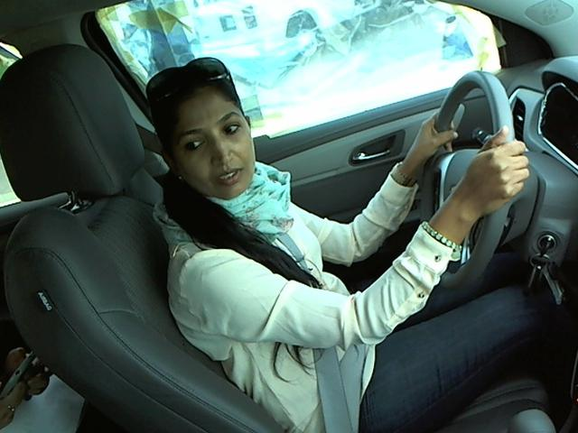

```
  Proba:
[ 1.  0.  0.  0.  0.  0.  0.  0.  0.  0.]
Min Proba for cls: c0; desc: normal driving; proba: 0.2345; nObsNew: 1
  /Users/bbalaji-2012/Documents/Work/DataScience/Kaggle/StateFarm/data/imgs/test/img_48839.jpg:
```

[figure not shown]

```
  Proba:
[ 0.2345  0.0771  0.2317  0.2207  0.0579  0.001   0.0613  0.0001  0.0129
  0.1029]
  next best class: talking on the phone - right


Max Proba for cls: c1; desc: texting - right; proba: 1.0000; nObsNew: 1
  /Users/bbalaji-2012/Documents/Work/DataScience/Kaggle/StateFarm/data/imgs/test/img_91185.jpg:
```

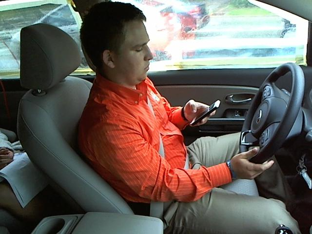

```
  Proba:
[ 0.  1.  0.  0.  0.  0.  0.  0.  0.  0.]
Min Proba for cls: c1; desc: texting - right; proba: 0.2005; nObsNew: 1
  /Users/bbalaji-2012/Documents/Work/DataScience/Kaggle/StateFarm/data/imgs/test/img_490.jpg:
```

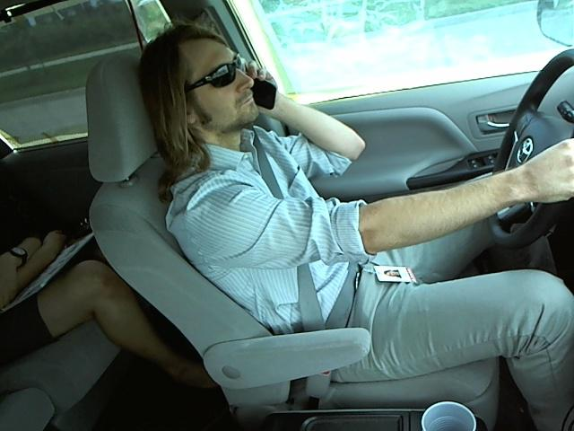

```
  Proba:
[ 0.0236  0.2005  0.      0.128   0.1182  0.1661  0.1558  0.0005  0.1783
  0.0293]
  next best class: hair and makeup


Max Proba for cls: c2; desc: talking on the phone - right; proba: 1.0000; nObsNew: 1
  /Users/bbalaji-2012/Documents/Work/DataScience/Kaggle/StateFarm/data/imgs/test/img_45248.jpg:
```

[figure not shown]

```
  Proba:
[ 0.  0.  1.  0.  0.  0.  0.  0.  0.  0.]
Min Proba for cls: c2; desc: talking on the phone - right; proba: 0.2234; nObsNew: 1
  /Users/bbalaji-2012/Documents/Work/DataScience/Kaggle/StateFarm/data/imgs/test/img_53769.jpg:
```

[figure not shown]

```
  Proba:
[ 0.1674  0.0464  0.2234  0.0081  0.146   0.0048  0.1542  0.0998  0.007
  0.1426]
  next best class: normal driving


Max Proba for cls: c3; desc: texting - left; proba: 1.0000; nObsNew: 1
  /Users/bbalaji-2012/Documents/Work/DataScience/Kaggle/StateFarm/data/imgs/test/img_65853.jpg:
```

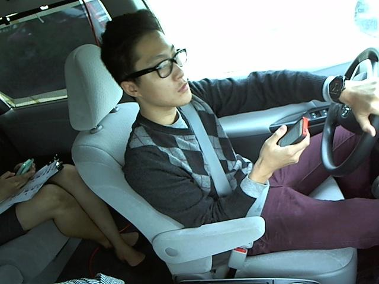

```
  Proba:
[ 0.  0.  0.  1.  0.  0.  0.  0.  0.  0.]
Min Proba for cls: c3; desc: texting - left; proba: 0.2278; nObsNew: 1
  /Users/bbalaji-2012/Documents/Work/DataScience/Kaggle/StateFarm/data/imgs/test/img_57360.jpg:
```

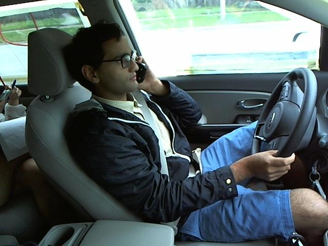

```
  Proba:
[ 0.0099  0.1661  0.1746  0.2278  0.1476  0.1391  0.1026  0.      0.0322
  0.    ]
  next best class: talking on the phone - right


Max Proba for cls: c4; desc: talking on the phone - left; proba: 1.0000; nObsNew: 1
  /Users/bbalaji-2012/Documents/Work/DataScience/Kaggle/StateFarm/data/imgs/test/img_40761.jpg:
```

[figure not shown]

```
  Proba:
[ 0.  0.  0.  0.  1.  0.  0.  0.  0.  0.]
Min Proba for cls: c4; desc: talking on the phone - left; proba: 0.2027; nObsNew: 1
  /Users/bbalaji-2012/Documents/Work/DataScience/Kaggle/StateFarm/data/imgs/test/img_19776.jpg:
```

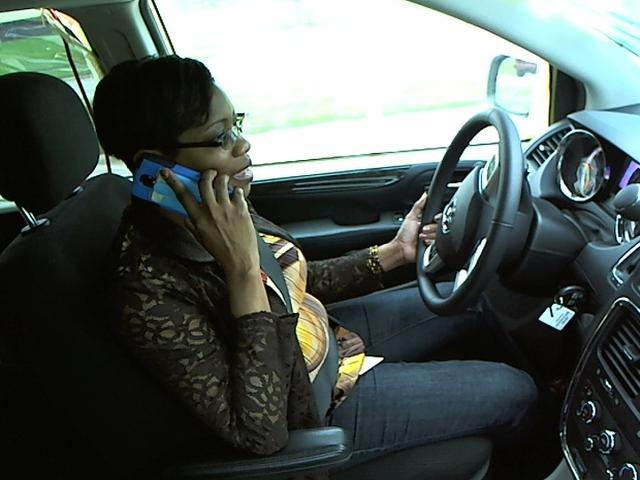

```
  Proba:
[ 0.0891  0.0716  0.1568  0.008   0.2027  0.0983  0.1471  0.      0.0919
  0.1345]
  next best class: talking on the phone - right


Max Proba for cls: c5; desc: operating the radio; proba: 1.0000; nObsNew: 107
  /Users/bbalaji-2012/Documents/Work/DataScience/Kaggle/StateFarm/data/imgs/test/img_100652.jpg:
```

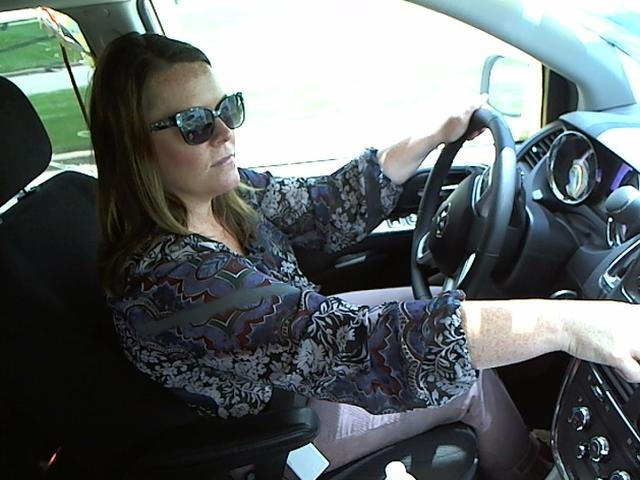

```
  Proba:
[ 0.  0.  0.  0.  0.  1.  0.  0.  0.  0.]
Min Proba for cls: c5; desc: operating the radio; proba: 0.2257; nObsNew: 1
  /Users/bbalaji-2012/Documents/Work/DataScience/Kaggle/StateFarm/data/imgs/test/img_51092.jpg:
```

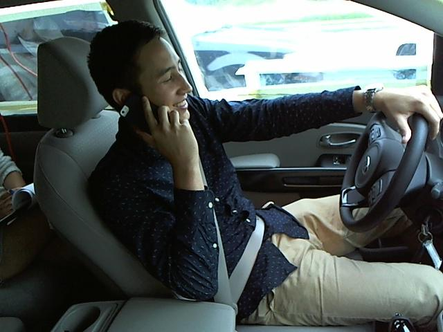

```
  Proba:
[ 0.0147  0.0629  0.0102  0.1632  0.0045  0.2257  0.2233  0.      0.1055
  0.19  ]
  next best class: drinking


Max Proba for cls: c6; desc: drinking; proba: 1.0000; nObsNew: 1
  /Users/bbalaji-2012/Documents/Work/DataScience/Kaggle/StateFarm/data/imgs/test/img_89962.jpg:
```

[8 more figures not shown]

```
  Proba:
[ 0.1663  0.0047  0.0958  0.1585  0.0029  0.0111  0.0282  0.1939  0.1383
  0.2002]
  next best class: reaching behind
```

```python
for clsIx, cls in enumerate(glbRspClass):
    clsMsk = glbYNewPred == clsIx
    clsObsNewRspPredProba = glbYNewPredProba[clsMsk, :]
    clsObsNewIdn = [glbINew[ixMsk] for ixMsk in xrange(len(glbINew)) \
                    if clsMsk[ixMsk]]
    print '\n'

    maxClsProba = np.max(clsObsNewRspPredProba[:, clsIx])
    maxObsNewRspPredProba = clsObsNewRspPredProba[:, clsIx] == maxClsProba
    print 'Max Proba for cls: %s; desc: %s; proba: %0.4f; nObsNew: %d' % \
        (cls, glbRspClassDesc[cls], maxClsProba, maxObsNewRspPredProba.sum())
    imgFilePth = os.getcwd() + '/data/' + glbDataFile['newFoldersPth'] + '/' + \
                    clsObsNewIdn[np.argmax(clsObsNewRspPredProba[:, clsIx])]
    print '  %s:' % imgFilePth
    jpgfile = Image(imgFilePth, format = 'jpg',
                        width = glbImg['size'] * 4, height = glbImg['size'] * 4)
    display(jpgfile)
    print '  Proba:';
    print np.array_str(clsObsNewRspPredProba[np.argmax(clsObsNewRspPredProba[:, clsIx]), :],
                       precision=4, suppress_small=True)

    minClsProba = np.min(clsObsNewRspPredProba[:, clsIx])
    minObsNewRspPredProba = clsObsNewRspPredProba[:, clsIx] == minClsProba
    print 'Min Proba for cls: %s; desc: %s; proba: %0.4f; nObsNew: %d' % \
        (cls, glbRspClassDesc[cls], minClsProba, minObsNewRspPredProba.sum())
    imgFilePth = os.getcwd() + '/data/' + glbDataFile['newFoldersPth'] + '/' + \
                    clsObsNewIdn[np.argmin(clsObsNewRspPredProba[:, clsIx])]
    print '  %s:' % imgFilePth
    jpgfile = Image(imgFilePth, format = 'jpg',
                        width = glbImg['size'] * 4, height = glbImg['size'] * 4)
    display(jpgfile)
    print '  Proba:';
    print np.array_str(clsObsNewRspPredProba[np.argmin(clsObsNewRspPredProba[:, clsIx]), :],
                       precision=4, suppress_small=True)
    thsObsNewRspPredProba = clsObsNewRspPredProba[np.argmin(clsObsNewRspPredProba[:, clsIx]), :]
    thsObsNewRspPredProba[clsIx] = 0
    print '  next best class: %s' % \
        (glbRspClassDesc[glbRspClass[np.argmax(thsObsNewRspPredProba)]])
```

## Output submission

```python
sbmObsNewDf = pd.DataFrame(glbYNewPredProba)
sbmObsNewDf.columns = glbRspClass
sbmObsNewDf['img'] = glbINew
sbmObsNewDf = (sbmObsNewDf
                .set_index(['img'],
                           drop = False)
                .sort_values('img')
                )
sbmObsNewDf = sbmObsNewDf[['img'] + glbRspClass]
print sbmObsNewDf.head()
print sbmObsNewDf.tail()
```

```
                           img            c0            c1            c2  \
img
img_1.jpg            img_1.jpg  1.022341e-09  1.291037e-13  1.555788e-06
img_10.jpg          img_10.jpg  2.402234e-06  5.292969e-06  9.821139e-05
img_100.jpg        img_100.jpg  8.845692e-01  3.524664e-04  2.565228e-06
img_1000.jpg      img_1000.jpg  1.225707e-02  1.982485e-02  4.778495e-02
img_100000.jpg  img_100000.jpg  1.405662e-06  4.824674e-07  2.834371e-07

                          c3            c4            c5            c6  \
img
img_1.jpg       1.410185e-14  3.884833e-10  9.999970e-01  1.474044e-06
img_10.jpg      2.949705e-01  1.301745e-04  7.047829e-01  2.255957e-09
img_100.jpg     3.062941e-04  1.676451e-04  3.745919e-07  3.374660e-06
img_1000.jpg    4.757002e-07  8.205907e-01  3.033170e-05  9.736010e-02
img_100000.jpg  2.272234e-04  9.805247e-01  7.948852e-08  5.065448e-09

                          c7            c8            c9
img
img_1.jpg       3.129472e-11  1.022849e-11  2.690043e-09
img_10.jpg      1.052496e-05  6.288445e-08  1.646834e-08
img_100.jpg     1.175810e-06  2.099598e-03  1.124972e-01
img_1000.jpg    2.921651e-05  1.652298e-03  4.698370e-04
img_100000.jpg  5.099652e-08  1.924536e-02  4.479208e-07
                         img            c0        c1        c2            c3  \
img
img_99994.jpg  img_99994.jpg  7.162805e-05  0.000320  0.000009  9.440665e-09
img_99995.jpg  img_99995.jpg  1.071301e-03  0.016465  0.166696  1.538394e-02
img_99996.jpg  img_99996.jpg  4.202174e-04  0.000978  0.000348  3.626455e-03
img_99998.jpg  img_99998.jpg  3.616881e-05  0.000068  0.106104  3.118407e-07
img_99999.jpg  img_99999.jpg  8.577208e-09  0.368445  0.000013  4.160142e-07

                     c4        c5        c6            c7        c8  \
img
img_99994.jpg  0.012948  0.940612  0.000156  1.051636e-02  0.034079
img_99995.jpg  0.200807  0.008122  0.061560  4.564922e-03  0.041106
img_99996.jpg  0.986504  0.000037  0.000722  1.394862e-03  0.005899
img_99998.jpg  0.001297  0.000041  0.891460  3.005408e-04  0.000338
img_99999.jpg  0.002124  0.001933  0.371602  5.274902e-12  0.255883

                         c9
img
img_99994.jpg  1.286955e-03
img_99995.jpg  4.842241e-01
img_99996.jpg  7.004915e-05
img_99998.jpg  3.554169e-04
img_99999.jpg  2.753189e-07
```

```python
sbmObsNewDf.to_csv('img_03_fit_lgtRgrTf_SFDD_sbmt.csv', index = False)
```

```python
print 'LeaderBoard metric for this submission:%0.5f' % (3.93155)
print 'Best score yet:%s :%0.5f' % \
    ('img_02_fit_lgtRgr_SFDD_sbmt.csv', 2.63892)
```

```
LeaderBoard metric for this submission:3.93155
Best score yet:img_02_fit_lgtRgr_SFDD_sbmt.csv :2.63892
```

## Stop here

Following code should be in img*04_fit_lgtRgrSGDTf*

Let's now switch to stochastic gradient descent training instead, which is much faster.

The graph will be similar, except that instead of holding all the training data into a constant node, we create a `Placeholder` node which will be fed actual data at every call of `sesion.run()`.

```python
import pandas as pd
models = pd.DataFrame({'nRELUs': [0]})
#models.ix[0, 'accuracy_scoreTest'] = 0
print models
```

```
   nRELUs
0       0
```

```python
batch_size = 128

graph = tf.Graph()
with graph.as_default():

  # Input data. For the training data, we use a placeholder that will be fed
  # at run time with a training minibatch.
  tfwObsFitFtr = tf.placeholder(tf.float32,
                                    shape=(batch_size, glbImg['size'] * glbImg['size']))
  tfwObsFitRsp = tf.placeholder(tf.float32, shape=(batch_size, glbRspClassN))
  tfwObsVldFtr = tf.constant(glbXVld)
  tfwObsNewFtr = tf.constant(glbXNew)

  # Variables.
  tfwW = tf.Variable(
    tf.truncated_normal([glbImg['size'] * glbImg['size'], glbRspClassN]))
  tfwB = tf.Variable(tf.zeros([glbRspClassN]))
  print(tfwW.initialized_value())
  print(tfwB.initialized_value())

  # Training computation.
  logits = tf.matmul(tfwObsFitFtr, tfwW) + tfwB
  loss = tf.reduce_mean(
    tf.nn.softmax_cross_entropy_with_logits(logits, tfwObsFitRsp))

  # Optimizer.
  optimizer = tf.train.GradientDescentOptimizer(0.5).minimize(loss)

  # Predictions for the training, validation, and test data.
  tfwObsTrnPred = tf.nn.softmax(logits)
  tfwObsVldPred = tf.nn.softmax(
    tf.matmul(tfwObsVldFtr, tfwW) + tfwB)
  tfwObsNewPred = tf.nn.softmax(tf.matmul(tfwObsNewFtr, tfwW) + tfwB)
```

[output not shown]

Let's run it:

```python
nStepsTfw = 3001

with tf.Session(graph=graph) as session:
  tf.initialize_all_variables().run()
  print("Initialized")
  for step in range(nStepsTfw):
    # Pick an offset within the training data, which has been randomized.
    # Note: we could use better randomization across epochs.
    offset = (step * batch_size) % (glbYFit.shape[0] - batch_size)
    # Generate a minibatch.
    batch_data = glbXFit[offset:(offset + batch_size), :]
    batch_labels = glbYFit[offset:(offset + batch_size), :]
    # Prepare a dictionary telling the session where to feed the minibatch.
    # The key of the dictionary is the placeholder node of the graph to be fed,
    # and the value is the numpy array to feed to it.
    feed_dict = {tfwObsFitFtr : batch_data, tfwObsFitRsp : batch_labels}
    _, l, predictions = session.run(
      [optimizer, loss, tfwObsTrnPred], feed_dict=feed_dict)
    if (step % 500 == 0):
      print("Minibatch loss at step %d: %f" % (step, l))
      print("Minibatch accuracy_score: %.1f%%" % accuracy_score(predictions, batch_labels))
      print("Validation accuracy_score: %.1f%%" % accuracy_score(
        tfwObsVldPred.eval(), glbYVld))
  print("Test accuracy_score: %.1f%%" % accuracy_score(tfwObsNewPred.eval(), glbYNew))
  models.ix[0, 'accuracy_scoreVld'] = accuracy_score(tfwObsVldPred.eval(), glbYVld)
  models.ix[0, 'accuracy_scoreTst'] = accuracy_score( tfwObsNewPred.eval(),  glbYNew)
```

[output not shown]

```python
models.ix[0, 'graph'] = graph
print(models)
```

[output not shown]

## Problem

Turn the logistic regression example with SGD into a 1-hidden layer neural network with rectified linear units (nn.relu()) and 1024 hidden nodes. This model should improve your validation / test accuracy_score.

```python
nRELUs = [2 ** thsRelu for thsRelu in xrange(11)]
print(nRELUs)
for thsRelu in nRELUs:
    models.ix[thsRelu, 'nRELUs'] = thsRelu

print models
```

[output not shown]

```python
thsRelu = nRELUs[9]
batch_size = 128

graph = tf.Graph()
with graph.as_default():

  # Input data. For the training data, we use a placeholder that will be fed
  # at run time with a training minibatch.
  tfwObsFitFtr = tf.placeholder(tf.float32,
                                    shape=(batch_size, glbImg['size'] * glbImg['size']))
  tfwObsFitRsp = tf.placeholder(tf.float32, shape=(batch_size, glbRspClassN))
  tfwObsVldFtr = tf.constant(glbXVld)
  tfwObsNewFtr = tf.constant(glbXNew)

  # Variables.
  tfwW1 = tf.Variable(
    tf.truncated_normal([glbImg['size'] * glbImg['size'], thsRelu]), name = 'tfwW1')
  tfwB1 = tf.Variable(tf.zeros([thsRelu]), name = 'tfwB1')
  tfwW2 = tf.Variable(
    tf.truncated_normal([thsRelu, glbRspClassN]), name = 'tfwW2')
  tfwB2 = tf.Variable(tf.zeros([glbRspClassN]), name = 'tfwB2')
  print(tfwW1.initialized_value())
  print(tfwB1.initialized_value())
  #print(relus.initialized_value())
  print(tfwW2.initialized_value())
  print(tfwB2.initialized_value())
  #tf.Print(relus, [relus])

  # Training computation.
  layer1 = tf.matmul(tfwObsFitFtr, tfwW1) + tfwB1
  layer2 = tf.nn.relu(layer1)
  layer3 = tf.matmul(layer2, tfwW2) + tfwB2
  loss = tf.reduce_mean(
    tf.nn.softmax_cross_entropy_with_logits(layer3, tfwObsFitRsp))

  # Optimizer.
  optimizer = tf.train.GradientDescentOptimizer(0.5).minimize(loss)

  # Predictions for the training, validation, and test data.
  tfwObsTrnPred = tf.nn.softmax(layer3)
  tfwObsVldPred = tf.nn.softmax(
    tf.matmul(tf.nn.relu(tf.matmul(tfwObsVldFtr, tfwW1) + tfwB1), tfwW2) + tfwB2)
  tfwObsNewPred = tf.nn.softmax(
    tf.matmul(tf.nn.relu(tf.matmul(tfwObsNewFtr, tfwW1) + tfwB1), tfwW2) + tfwB2)
```

[output not shown]

```python
nStepsTfw = 3001

with tf.Session(graph=graph) as session:
  tf.initialize_all_variables().run()
  print("Initialized")
  for step in range(nStepsTfw):
    # Pick an offset within the training data, which has been randomized.
    # Note: we could use better randomization across epochs.
    offset = (step * batch_size) % (glbYFit.shape[0] - batch_size)
    # Generate a minibatch.
    batch_data = glbXFit[offset:(offset + batch_size), :]
    batch_labels = glbYFit[offset:(offset + batch_size), :]
    # Prepare a dictionary telling the session where to feed the minibatch.
    # The key of the dictionary is the placeholder node of the graph to be fed,
    # and the value is the numpy array to feed to it.
    feed_dict = {tfwObsFitFtr : batch_data, tfwObsFitRsp : batch_labels}
    _, l, predictions = session.run(
      [optimizer, loss, tfwObsTrnPred], feed_dict=feed_dict)
    if (step % 500 == 0):
      print("Minibatch loss at step %d: %f" % (step, l))
      print("Minibatch accuracy_score: %.1f%%" % accuracy_score(predictions, batch_labels))
      print("Validation accuracy_score: %.1f%%" % accuracy_score(
        tfwObsVldPred.eval(), glbYVld))
  print("Test accuracy_score: %.1f%%" % accuracy_score(tfwObsNewPred.eval(), glbYNew))
  models.ix[thsRelu, 'accuracy_scoreVld'] = accuracy_score(tfwObsVldPred.eval(), glbYVld)
  models.ix[thsRelu, 'accuracy_scoreTst'] = accuracy_score( tfwObsNewPred.eval(),  glbYNew)
  models.ix[thsRelu, 'graph'] = graph
  print(models)
```

[output not shown]

[figure not shown]

```python
plt.figure()
#plt.plot(models['nRELUs'], models['accuracy_score.fit'], 'bo-', label = 'fit')
plt.plot(models['nRELUs'], models['accuracy_scoreVld'], 'rs-', label = 'vld')
plt.plot(models['nRELUs'], models['accuracy_scoreTst'], 'gp-', label = 'new')
plt.legend(loc = 'lower right')
plt.title("accuracy_score")
plt.xscale('symlog', basex=2)
axes = plt.gca()
axes.set_xlabel('nRELUs')
# axes.set_xlim([mdlDF['l1_penalty'][mdlDF['RSS.vld'].argmin()] / 10 ** 2, \
#                mdlDF['l1_penalty'][mdlDF['RSS.vld'].argmin()] * 10 ** 2])
# axes.set_ylim([0, mdlDF['RSS.vld'].min() * 1.5])
plt.show()
```